# Week 6 Homework

Shelbie Ishimaru

2024-10-07

In this RMarkdown file, we will run through how to…

1. Manipulate a data frame efficiently using the tidyverse
2. Create a table using the *kableExtra* package
3. Make a figure using ggplot
4. Utilize fun color palettes to make **BEAUTIFUL** figures

So let’s get this party started!

### Load Libraries

The first thing we want to do is load our libraries. Below are all of the important libraries needed to accomplish our goals and a short description of what they do.

```r
library(tidyverse) #for data manipulation
library(here) #for unbreakable file paths
library(kableExtra) #for building tables
library(beyonce) #a fun color palette
```

### Load and Inspect the Data

Next we want to load in our data. We are going to be using chemical data collected from *Silbiger et al. 2020*. Once we load the data we want to look at it so we can understand what information we are working with.

```r
ChemData<-read_csv(here("Week_06","Data", "chemicaldata_maunalua.csv")) #read in new data set
glimpse(ChemData) #look at the data frame
```

```
## Rows: 355
## Columns: 15
## $ Waypoint    <dbl> 1, 2, 3, 4, 5, 6, 7, 8, 9, 10, 11, 12, 13, 14, 15, 16, 17,…
## $ Zone        <chr> "Transition", "Transition", "Transition", "Transition", "D…
## $ Lat         <dbl> 21.27531, 21.27523, 21.27504, 21.27449, 21.27503, 21.27485…
## $ Long        <dbl> -157.7618, -157.7627, -157.7633, -157.7640, -157.7617, -15…
## $ Site        <chr> "W", "W", "W", "W", "W", "W", "W", "W", "W", "W", "W", "W"…
## $ Season      <chr> "SPRING", "SPRING", "SPRING", "SPRING", "SPRING", "SPRING"…
## $ Tide_time   <chr> "Low_Day", "Low_Day", "Low_Day", "Low_Day", "Low_Day", "Lo…
## $ Temp_in     <dbl> 23.75506, 23.53256, 22.63450, 24.01982, 23.26102, 24.00517…
## $ Salinity    <dbl> 27.74029, 30.61192, 28.37008, 32.82124, 29.12293, 34.02018…
## $ Phosphate   <dbl> 0.54, 0.36, 0.50, 0.25, 0.50, 0.13, 0.28, 0.15, 0.23, 0.11…
## $ Silicate    <dbl> 157.93, 92.59, 143.60, 42.32, 126.47, 15.04, 56.31, 23.10,…
## $ NN          <dbl> 7.92, 3.37, 7.29, 0.79, 7.45, 0.46, 1.59, 0.34, 1.91, 0.25…
## $ pH          <dbl> 7.909, 7.965, 8.023, 7.995, 8.005, 8.019, 8.003, 7.978, 7.…
## $ TA          <dbl> 2161.482, 2145.828, 2272.391, 2219.583, 2151.826, 2216.758…
## $ percent_sgd <dbl> 20.4043928, 11.9625323, 18.5529716, 5.4677003, 16.3397933,…
```

### Data Manipulation

Now that the data is loaded we can begin manipulating our data so that it can be used for creating tables and figures. Below I am creating a clean data frame by removing *NA* values, pivoting the data, and summarizing to obtain mean nutrient concentrations by sampling zone.

```r
chem_clean <- ChemData %>% #creates a new data frame and pulls in our data frame
drop_na() %>% #filters out everything that is not a complete row
  select(Zone, NN, Silicate, Phosphate) %>% #selects the cols we are interested for calculations
  pivot_longer(cols = NN:Phosphate, #the cols you want to pivot. This says select the NN, silicate, and phosphate cols
               names_to = "Variables", #the names of the new cols with all the column names
               values_to = "Values") %>% #names of the new column with all the values
  group_by(Variables, Zone) %>% #groups by our desired variables
  summarise(Mean = mean(Values, na.rm = T)) #calculates the mean NN, silicate, and phosphate by zone
```

### Create a Table with Kable

After cleaning the data, we can now create a table for publications and presentations. Below I show how the *kableExtra* package can be used to make high quality tables.

```r
chem_table <- chem_clean %>% #creates a new data frame and pulls in our data frame
   kbl()  %>% # make it a kable table
  kable_classic_2(lightable_options = "striped") %>% #makes every other row a grey background
  kable_styling(full_width = FALSE, row_label_position = "c") #make table narrower and centers the row headers
chem_table #call the table so it can be shown in the markdown HTML
```

| Variables | Zone | Mean |
| --- | --- | --- |
| NN | Ambient | 0.2793069 |
| NN | Diffuse | 1.5509353 |
| NN | Offshore | 0.1166667 |
| NN | Transition | 4.1751389 |
| Phosphate | Ambient | 0.1167327 |
| Phosphate | Diffuse | 0.1597122 |
| Phosphate | Offshore | 0.1583333 |
| Phosphate | Transition | 0.2479167 |
| Silicate | Ambient | 2.4096040 |
| Silicate | Diffuse | 14.3753237 |
| Silicate | Offshore | 1.7183333 |
| Silicate | Transition | 37.4955556 |

### Make a Plot

Finally we can make a figure ggplot. Below I will show how to create a plot that shows changes in Nitrate+Nitrite, Phosphate, and Silicate by Sampling Zone. To add excitement to my plot, I used the [Beyonce color palette](https://github.com/dill/beyonce)!

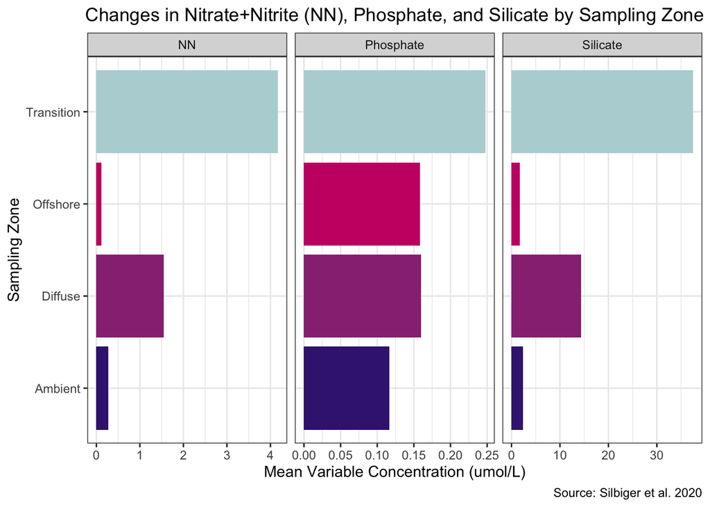

```r
chem_clean %>%
  ggplot(aes(x = Mean, #x-axis is mean variable concentration
             y = Zone, fill= Zone)) + #y-axis is sampling zone
  geom_bar(stat= "identity", #plot the given means by zone
           position= position_dodge(), #creates clustered bar plot (by zone)
           show.legend = F) + #removes legend
  facet_wrap(~Variables, scales= "free_x") +
  labs(x= "Mean Variable Concentration (umol/L)", #x-axis label
       y= "Sampling Zone", #y-axis label
       title= "Changes in Nitrate+Nitrite (NN), Phosphate, and Silicate by Sampling Zone", #plot title
       caption= "Source: Silbiger et al. 2020") + #adds caption of where we got the data
  scale_fill_manual(values= beyonce_palette(11)) + #changes colors of bars to be Beyonce themed!
  theme_bw() + #change theme so we have a white background with grey grid lines and black outline
    theme(axis.title= element_text(size= 11), #change axes text size
        plot.title= element_text(hjust= 0.5), #change title text size
        plot.caption.position = "plot") #make caption on the bottom right of the page
```

Thanks for reading!! If you enjoyed this Markdown file, checkout my [MBIO 612 github repository](https://github.com/OCN-682-UH/Ishimaru) to see what I’ve been learning! :)